# Hedoniske boligprismodeller og romlig avhengighet i Lucas County, Ohio

Term paper i MSB205

Ivan Stordal & Antonio Isa Jakobsen

28.10.2026

# Oppgave 1

## i

```
   price yrbuilt  stories  TLA     wall beds baths halfbaths frontage depth
1 303000    1978 one+half 3273  partbrk    4     3         1      177     0
2  92000    1957      one  920 metlvnyl    2     1         0      100     0
3  90000    1937      two 1956 stucdrvt    3     1         0      192     0
4 330000    1887 one+half 1430     wood    4     1         0      200   217
5 185000    1978      two 2208  partbrk    3     2         1      241     0
6 100000    1989      one 1232     wood    1     1         0      154  1420
     garage garagesqft rooms lotsize  sdate avalue s1993 s1994 s1995 s1996
1  attached        625    12   53496 960423 306514     0     0     0     1
2  detached        308     4   37900 970421  84628     0     0     0     0
3  attached        480     7   52900 931101 126514     1     0     0     0
4 no garage          0     7   43560 971223 199228     0     0     0     0
5  attached        528     7  225800 950807 192514     0     0     1     0
6  detached       1200     5  214100 931101 107914     1     0     0     0
  s1997 s1998 syear  age
1     0     0  1996 0.21
2     1     0  1997 0.42
3     0     0  1993 0.62
4     1     0  1997 1.12
5     0     0  1995 0.21
6     0     0  1993 0.10
```

```
 [1] "price"      "yrbuilt"    "stories"    "TLA"        "wall"
 [6] "beds"       "baths"      "halfbaths"  "frontage"   "depth"
[11] "garage"     "garagesqft" "rooms"      "lotsize"    "sdate"
[16] "avalue"     "s1993"      "s1994"      "s1995"      "s1996"
[21] "s1997"      "s1998"      "syear"      "age"
```

```
Formal class 'SpatialPointsDataFrame' [package "sp"] with 5 slots
  ..@ data       :'data.frame': 25357 obs. of  24 variables:
  .. ..$ price     : int [1:25357] 303000 92000 90000 330000 185000 100000 43065 305000 56493 50000 ...
  .. ..$ yrbuilt   : int [1:25357] 1978 1957 1937 1887 1978 1989 1927 1990 1877 1936 ...
  .. ..$ stories   : Factor w/ 7 levels "one","bilevel",..: 4 1 5 4 5 1 1 4 1 1 ...
  .. ..$ TLA       : int [1:25357] 3273 920 1956 1430 2208 1232 832 3011 1034 960 ...
  .. ..$ wall      : Factor w/ 7 levels "stucdrvt","ccbtile",..: 7 3 1 6 7 6 6 7 6 6 ...
  .. ..$ beds      : num [1:25357] 4 2 3 4 3 1 2 3 3 2 ...
  .. ..$ baths     : num [1:25357] 3 1 1 1 2 1 1 2 1 1 ...
  .. ..$ halfbaths : num [1:25357] 1 0 0 0 1 0 0 1 0 0 ...
  .. ..$ frontage  : int [1:25357] 177 100 192 200 241 154 320 362 500 220 ...
  .. ..$ depth     : int [1:25357] 0 0 0 217 0 1420 0 0 990 0 ...
  .. ..$ garage    : Factor w/ 5 levels "no garage","basement",..: 3 4 3 1 3 4 4 3 4 4 ...
  .. ..$ garagesqft: int [1:25357] 625 308 480 0 528 1200 360 672 624 780 ...
  .. ..$ rooms     : int [1:25357] 12 4 7 7 7 5 4 6 7 6 ...
  .. ..$ lotsize   : int [1:25357] 53496 37900 52900 43560 225800 214100 23500 324900 354200 37000 ...
  .. ..$ sdate     : int [1:25357] 960423 970421 931101 971223 950807 931101 951031 931229 960222 960607 ...
  .. ..$ avalue    : int [1:25357] 306514 84628 126514 199228 192514 107914 49028 263400 76600 50714 ...
  .. ..$ s1993     : int [1:25357] 0 0 1 0 0 1 0 1 0 0 ...
  .. ..$ s1994     : int [1:25357] 0 0 0 0 0 0 0 0 0 0 ...
  .. ..$ s1995     : int [1:25357] 0 0 0 0 1 0 1 0 0 0 ...
  .. ..$ s1996     : int [1:25357] 1 0 0 0 0 0 0 0 1 1 ...
  .. ..$ s1997     : int [1:25357] 0 1 0 1 0 0 0 0 0 0 ...
  .. ..$ s1998     : int [1:25357] 0 0 0 0 0 0 0 0 0 0 ...
  .. ..$ syear     : Factor w/ 6 levels "1993","1994",..: 4 5 1 5 3 1 3 1 4 4 ...
  .. ..$ age       : num [1:25357] 0.21 0.42 0.62 1.12 0.21 0.1 0.72 0.09 1.22 0.63 ...
  ..@ coords.nrs : num(0)
  ..@ coords     : num [1:25357, 1:2] 484668 484876 485248 485764 488150 ...
  .. ..- attr(*, "dimnames")=List of 2
  .. .. ..$ : NULL
  .. .. ..$ : chr [1:2] "long" "lat"
  ..@ bbox       : num [1:2, 1:2] 484575 195270 538364 229836
  .. ..- attr(*, "dimnames")=List of 2
  .. .. ..$ : chr [1:2] "long" "lat"
  .. .. ..$ : chr [1:2] "min" "max"
  ..@ proj4string:Formal class 'CRS' [package "sp"] with 1 slot
  .. .. ..@ projargs: chr "+proj=lcc +lat_0=39.6666666666667 +lon_0=-82.5 +lat_1=41.7 +lat_2=40.4333333333333 +x_0=600000 +y_0=0 +ellps=GR"| __truncated__
  .. .. ..$ comment: chr "PROJCRS[\"unknown\",\n    BASEGEOGCRS[\"unknown\",\n        DATUM[\"Unknown based on GRS80 ellipsoid\",\n      "| __truncated__
```

```
[1] 25357    24
```

```
[1] "SpatialPointsDataFrame"
attr(,"package")
[1] "sp"
```

## ii

```
[1] "1996-04-23" "1997-04-21" "1993-11-01" "1997-12-23" "1995-08-07"
[6] "1993-11-01"
```

```
[1] "1993-01-04" "1998-10-05"
```

```
 [1] "1996-04" "1997-04" "1993-11" "1997-12" "1995-08" "1995-10" "1993-12"
 [8] "1996-02" "1996-06" "1997-11" "1998-06" "1997-03" "1993-08" "1997-07"
[15] "1997-09" "1994-04" "1996-11" "1995-07" "1995-12" "1994-07" "1993-09"
[22] "1998-08" "1998-10" "1998-03" "1993-07" "1998-05" "1998-09" "1996-05"
[29] "1993-01" "1996-08" "1996-09" "1995-03" "1995-05" "1998-01" "1997-05"
[36] "1996-07" "1996-12" "1994-12" "1994-08" "1997-06" "1994-05" "1998-02"
[43] "1998-07" "1993-06" "1997-02" "1994-10" "1993-03" "1997-08" "1994-11"
[50] "1997-10" "1998-04" "1996-10" "1995-04" "1994-09" "1995-06" "1995-11"
[57] "1995-02" "1995-09" "1993-04" "1994-06" "1994-01" "1993-10" "1996-01"
[64] "1993-02" "1996-03" "1997-01" "1994-02" "1995-01" "1994-03" "1993-05"
```

## iii

```
[1] "sf"         "data.frame"
```

```
 [1] "price"      "yrbuilt"    "stories"    "TLA"        "wall"
 [6] "beds"       "baths"      "halfbaths"  "frontage"   "depth"
[11] "garage"     "garagesqft" "rooms"      "lotsize"    "sdate"
[16] "avalue"     "s1993"      "s1994"      "s1995"      "s1996"
[21] "s1997"      "s1998"      "syear"      "age"        "sdate_dato"
[26] "year_month" "geometry"
```

## iv

```
[1] "EPSG:2834"
```

## v & vi

```
   Min. 1st Qu.  Median    Mean 3rd Qu.    Max.
  0.573   5.292   7.895   8.790  11.184  38.731
```

```
[1] 25357
```

# Oppgave 2

## i

```
[1] 398
```

## iii

```
[1] "WGS 84 / Pseudo-Mercator"
```

```
[1] "EPSG:2834"
```

## iv

```
[1] 398
```

```
[1] 397
```

## v

```
[1] 397
```

## vi

```
[1] 25357
```

```
[1] 25352
```

```
 [1] "price"      "yrbuilt"    "stories"    "TLA"        "wall"
 [6] "beds"       "baths"      "halfbaths"  "frontage"   "depth"
[11] "garage"     "garagesqft" "rooms"      "lotsize"    "sdate"
[16] "avalue"     "s1993"      "s1994"      "s1995"      "s1996"
[21] "s1997"      "s1998"      "syear"      "age"        "sdate_dato"
[26] "year_month" "dist_CBD"   "ID"         "LINGISOPCT" "LOWINCPCT"
[31] "LESSHSPCT"  "OVER64PCT"  "VULEOPCT"   "PRE1960PCT" "PTRAF"
[36] "PWDIS"      "PNPL"       "PRMP"       "PTSDF"      "OZONE"
[41] "PM25"       "geometry"
```

# Oppgave 3

## i

```
[1] "a6f476ebc39366eea4382b1966385390e2462d0b"
```

## ii

```
[1] 128
```

## iii & iv

```
[1] 128
```

## v

```
        GEOID                                  NAME
1 39095990000 Census Tract 9900, Lucas County, Ohio
```

```
[1] 127
```

## vi

```
[1] "EPSG:2834"
```

## vii

```
[1] 127
```

## viii

```
[1] 25352
```

```
[1] 25351
```

```
 [1] "price"              "yrbuilt"            "stories"
 [4] "TLA"                "wall"               "beds"
 [7] "baths"              "halfbaths"          "frontage"
[10] "depth"              "garage"             "garagesqft"
[13] "rooms"              "lotsize"            "sdate"
[16] "avalue"             "s1993"              "s1994"
[19] "s1995"              "s1996"              "s1997"
[22] "s1998"              "syear"              "age"
[25] "sdate_dato"         "year_month"         "dist_CBD"
[28] "ID"                 "LINGISOPCT"         "LOWINCPCT"
[31] "LESSHSPCT"          "OVER64PCT"          "VULEOPCT"
[34] "PRE1960PCT"         "PTRAF"              "PWDIS"
[37] "PNPL"               "PRMP"               "PTSDF"
[40] "OZONE"              "PM25"               "GEOID"
[43] "NAME"               "income_pc"          "andel_hvit"
[46] "andel_svart"        "andel_asiatisk"     "andel_andre"
[49] "andel_blandet"      "mwtt"               "med_hh_inc"
[52] "andel_arbeidsledig" "andel_fattig"       "tract_name"
[55] "geometry"
```

## ix

```
     price           yrbuilt         stories           TLA
 Min.   :  2000   Min.   :1835   one     :12952   Min.   : 120
 1st Qu.: 41900   1st Qu.:1924   bilevel :  508   1st Qu.:1070
 Median : 65500   Median :1950   multilvl:  723   Median :1318
 Mean   : 79013   Mean   :1945   one+half: 3123   Mean   :1462
 3rd Qu.: 97000   3rd Qu.:1964   two     : 8041   3rd Qu.:1682
 Max.   :875000   Max.   :1998   two+half:    2   Max.   :7616
                                 three   :    2
       wall            beds           baths         halfbaths
 stucdrvt:  204   Min.   :0.000   Min.   :0.000   Min.   :0.0000
 ccbtile :  129   1st Qu.:3.000   1st Qu.:1.000   1st Qu.:0.0000
 metlvnyl: 4235   Median :3.000   Median :1.000   Median :0.0000
 brick   : 3632   Mean   :2.987   Mean   :1.242   Mean   :0.3412
 stone   :   86   3rd Qu.:3.000   3rd Qu.:1.000   3rd Qu.:1.0000
 wood    :11172   Max.   :9.000   Max.   :7.000   Max.   :3.0000
 partbrk : 5893
    frontage          depth              garage        garagesqft
 Min.   :  0.00   Min.   :   0.0   no garage: 3487   Min.   :   0.0
 1st Qu.: 40.00   1st Qu.: 105.0   basement :   78   1st Qu.: 280.0
 Median : 50.00   Median : 120.0   attached : 9016   Median : 396.0
 Mean   : 64.27   Mean   : 119.1   detached :12552   Mean   : 369.5
 3rd Qu.: 75.00   3rd Qu.: 140.0   carport  :  218   3rd Qu.: 484.0
 Max.   :810.00   Max.   :1587.0                     Max.   :5755.0

     rooms           lotsize           sdate            avalue
 Min.   : 1.000   Min.   :   702   Min.   :930104   Min.   :  1714
 1st Qu.: 5.000   1st Qu.:  4700   1st Qu.:941025   1st Qu.: 38514
 Median : 6.000   Median :  6800   Median :960520   Median : 59714
 Mean   : 6.115   Mean   : 13333   Mean   :957706   Mean   : 73636
 3rd Qu.: 7.000   3rd Qu.: 11100   3rd Qu.:970818   3rd Qu.: 91114
 Max.   :20.000   Max.   :429100   Max.   :981005   Max.   :788114

     s1993            s1994            s1995            s1996
 Min.   :0.0000   Min.   :0.0000   Min.   :0.0000   Min.   :0.0000
 1st Qu.:0.0000   1st Qu.:0.0000   1st Qu.:0.0000   1st Qu.:0.0000
 Median :0.0000   Median :0.0000   Median :0.0000   Median :0.0000
 Mean   :0.1286   Mean   :0.1466   Mean   :0.1629   Mean   :0.1908
 3rd Qu.:0.0000   3rd Qu.:0.0000   3rd Qu.:0.0000   3rd Qu.:0.0000
 Max.   :1.0000   Max.   :1.0000   Max.   :1.0000   Max.   :1.0000

```

[output cut: 61 more lines]

```
 3rd Qu.:0.043881   3rd Qu.:22.49   3rd Qu.: 53822   3rd Qu.:0.17622
 Max.   :0.137733   Max.   :31.63   Max.   :113299   Max.   :0.67849

  andel_fattig                                      tract_name
 Min.   :0.01493   Census Tract 92.02, Lucas County, Ohio:  684
 1st Qu.:0.07192   Census Tract 7, Lucas County, Ohio    :  644
 Median :0.14300   Census Tract 88, Lucas County, Ohio   :  480
 Mean   :0.17895   Census Tract 2, Lucas County, Ohio    :  409
 3rd Qu.:0.26308   Census Tract 86, Lucas County, Ohio   :  406
 Max.   :0.86341   Census Tract 72.03, Lucas County, Ohio:  403
                   (Other)                               :22325
          geometry
 POINT        :25351
 epsg:2834    :    0
 +proj=lcc ...:    0
```

```
# A tibble: 0 × 2
# ℹ 2 variables: variabel <chr>, antall_NA <int>
```

```
[1] 6
```

```
        GEOID     mwtt
1 39095003400 13.77817
2 39095003500 17.11628
3 39095003600 21.76549
4 39095003700 31.62547
5 39095003900 21.71627
```

```
   Min. 1st Qu.  Median    Mean 3rd Qu.    Max.
  12.16   19.79   21.18   21.55   23.15   31.63
```

```
        GEOID     mwtt
1 39095000200 22.22452
2 39095000300 19.30940
3 39095000400 20.23917
4 39095000600 21.23479
5 39095000700 20.97735
```

```
Deleting layer `Lucas County housing data' using driver `GPKG'
Writing layer `Lucas County housing data' to data source
  `lucas_full.gpkg' using driver `GPKG'
Writing 25351 features with 54 fields and geometry type Point.
```

# Oppgave 4

## Utforskende romlig dataanalyse

Før vi estimerer de hedoniske modellene, utfører vi en utforskende romlig analyse (EDA) i GeoDa. Datasettet inneholder 25 351 boligsalg etter koblingen med EJScreen- og ACS5-dataene. Seks av de opprinnelige 25 357 observasjonene falt bort i koblingen.

### Prisenes fordeling og beliggenhet

Salgsprisene varierer fra 2 000 til 875 000 dollar, med en median på 65 500 og et gjennomsnitt på 79 013 dollar. Fordelingen er høyreskjev, siden gjennomsnittet ligger over medianen og noen få boliger har svært høye priser. Halvparten av boligene ble solgt for mellom 41 900 og 97 000 dollar. Prisene er oppgitt i løpende dollar for perioden 1993–1998.

Prisene varierer også med avstanden til sentrum. Tabell 1 deler boligene i fem like store grupper etter avstand til CBD og viser medianprisen i hver gruppe.

Tabell 1: Medianpris etter avstand til CBD (femtedeler av boligene).

| Avstand til CBD (km) | Medianpris (USD) | Antall boliger |
| --- | --- | --- |
| [0.573,4.67] | 25000 | 5071 |
| (4.67,6.66] | 55000 | 5070 |
| (6.66,9.08] | 74500 | 5070 |
| (9.08,12.1] | 82000 | 5070 |
| (12.1,38.7] | 118500 | 5070 |

Medianprisen stiger jevnt med avstanden: den er 25 000 dollar for den femtedelen av boligene som ligger nærmest CBD, og 118 500 dollar for den femtedelen som ligger lengst unna. Dette er en enkel sammenheng som ikke tar hensyn til forskjeller i boligenes størrelse og alder, og den sier ikke at avstanden i seg selv forårsaker prisforskjellene. Vi kontrollerer for slike forhold i de hedoniske modellene.

### Bivariat lokal Moran’s I

For å finne ut hvor små og dyre, store og dyre, store og billige og små og billige boliger ligger, bruker vi bivariat lokal Moran’s I med boligareal (`TLA`) som første variabel og salgspris (`price`) som andre. Statistikken sammenligner boligarealet i et punkt med gjennomsnittsprisen hos naboene. Variablene standardiseres, så «høy» og «lav» betyr over og under gjennomsnittet i datasettet. Naboene er definert som de k nærmeste boligene, og vi bruker k = 3 og k = 10. «Dyr» betyr dermed at nabolaget har høye priser, ikke nødvendigvis at selve boligen er dyr.

De fire kategoriene tolkes slik:

- Høy-høy: store boliger i nabolag med høye priser
- Lav-lav: små boliger i nabolag med lave priser
- Høy-lav: store boliger i nabolag med lave priser
- Lav-høy: små boliger i nabolag med høye priser

Figur 1 og Figur 2 viser klyngekartene, og Tabell 2 viser antall boliger i hver kategori.

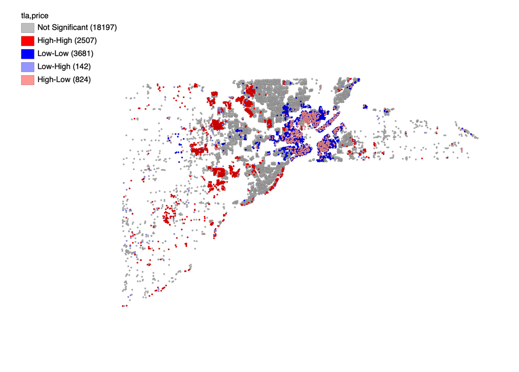

Figur 1: Bivariat lokal Moran’s I for boligareal (`TLA`) og salgspris (`price`), k = 3. Bare statistisk signifikante klynger er farget.

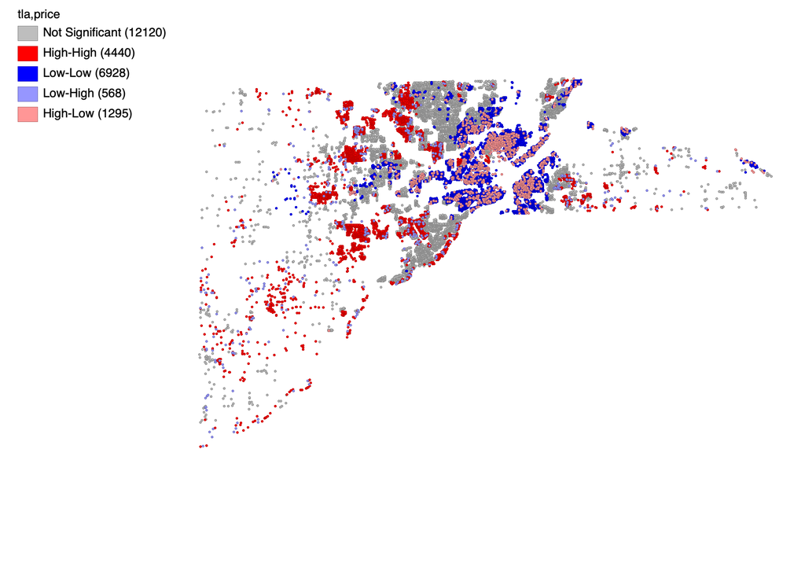

Figur 2: Bivariat lokal Moran’s I for boligareal (`TLA`) og salgspris (`price`), k = 10. Bare statistisk signifikante klynger er farget.

Tabell 2: Antall boliger per klyngetype, bivariat lokal Moran’s I (TLA og price).

| Klynge | k = 3 | k = 10 |
| --- | --- | --- |
| Høy-høy | 2507 | 4440 |
| Lav-lav | 3681 | 6928 |
| Høy-lav | 824 | 1295 |
| Lav-høy | 142 | 568 |
| Ikke signifikant | 18197 | 12120 |

Med k = 3 inngår 28 % av boligene (7 154 av 25 351) i en klynge som er signifikant på 5 %-nivå, mens andelen er 52 % med k = 10. Det er som forventet, siden et gjennomsnitt over flere naboer gir jevnere verdier og større sammenhengende klynger. Antall boliger som er signifikante på 0,1 %-nivå, øker fra 1 376 til 6 009.

For begge vekter er høy-høy og lav-lav de vanligste klyngene, og de utgjør om lag 86 % av boligene i signifikante klynger. Med k = 10 er det henholdsvis 4 440 og 6 928 boliger. De to blandede kategoriene er langt sjeldnere: høy-lav har 1 295 boliger og lav-høy 568. Blant de signifikante klyngene er det altså vanligst at store boliger ligger i nabolag med høye priser, og små boliger i nabolag med lave priser. Samtidig inngår nesten halvparten av boligene (12 120 med k = 10) ikke i noen signifikant klynge, så mønsteret gjelder ikke alle.

Høy-høy-klyngene ligger samlet i den vestlige, nordvestlige og sørvestlige delen av kartet. Lav-lav-klyngene og høy-lav-boligene ligger tett i den sentrale og østlige delen. Det er i tråd med Tabell 1, der de laveste prisene finnes nærmest sentrum. Det store, tett bebygde området i nord har få signifikante klynger. Mønstrene er i hovedsak de samme for k = 3 og k = 10, så resultatet er ikke avhengig av valget av vekt.

# Oppgave 5

## Datagrunnlag for modellene

Modellene bruker alle 25 351 boliger. Vi fjerner ingen observasjoner, siden radene må være uendret når vi lager vektmatriser i oppgave 7. Variablene som beskriver boligene, er areal, tomtestørrelse, alder ved salg (`age_sold`), antall rom, soverom, bad og halvbad, garasje, etasjer og veggmateriale. I tillegg har vi en dummy for de 138 boligene (0,5 %) som er solgt før byggeåret (negativ alder ved salg, minimum −3 år), siden prisen for slike boliger trolig ikke gjelder en ferdig bolig. Vi utelater `avalue` (vurdert verdi), som måler omtrent det samme som salgsprisen, og `age`, `syear` og `s1993`–`s1998`, siden `age` er alder i 1998 og tidsdummyene i `year_month` dekker salgstidspunktet. Etasjekategorier over én etasje er slått sammen, siden to av dem hadde svært få observasjoner. Miljøvariablene er standardisert (gjennomsnitt 0 og standardavvik 1), slik at koeffisientene gjelder per standardavvik og er sammenlignbare.

## Valg av modellform

Vi bruker den naturlige logaritmen av salgsprisen som avhengig variabel. Prisene er høyreskjeve (gjennomsnitt 79 013 og median 65 500 dollar, se oppgave 4), og logaritmen gjør fordelingen mer symmetrisk og lar oss tolke koeffisientene som prosentvise prisendringer. Boligareal (`TLA`) og tomtestørrelse (`lotsize`) er også logaritmert (log-log), så koeffisientene er elastisiteter: når boligarealet øker med 1 %, endres prisen med *β* %, alt annet likt. De øvrige variablene står i nivå (log-nivå). For en slik variabel gir én enhets økning en prisendring på omtrent 100*β* %, eksakt 100(*e*<sup>*β*</sup> − 1) %. For andelsvariabler målt fra 0 til 1 betyr én prosentpoengs økning omtrent *β* prosent endring i prisen, og for dummyvariabler er 100(*e*<sup>*β*</sup> − 1) % prisforskjellen mot referansekategorien.

Logaritmen er ikke definert for 0. `TLA` (minimum 120) og `lotsize` (minimum 702) er positive, men hvis en variabel kan være 0, kan man bruke log (1 + *x*) eller beholde den i nivå. Operasjoner som `/` og `+` må omsluttes av `I()` i en formel. Vi har derfor laget `inntekt_1000` (inntekt per capita i 1000 dollar) på forhånd.

## Hedoniske modeller

Modellene bygger på hedonisk pristeori. Bishop et al. (2020) beskriver at kjøpere velger bolig ut fra boligens egenskaper og stedsbundne goder, og at variasjon i goder blir kapitalisert i boligprisene. Maslianskaia-Pautrel og Baumont (2016) bruker romlige hedoniske modeller til å estimere implisitte priser for miljøegenskaper. Modellene utvides gradvis.

**Modell 1** inneholder bare boligens egenskaper og tidsdummyer (`year_month`). Salgene strekker seg over seks år, og Bishop et al. (2020) peker på at prisfunksjonen kan endre seg over tid, og at markedet bør avgrenses til ett byområde over få år.

**Modell 2** legger til avstand til CBD (`dist_CBD`), variabler fra ACS5 og demografiske variabler fra EJScreen som ikke er miljøvariabler. Fra ACS5 tar vi med inntekt per capita, etnisitetsandeler (`andel_hvit` er referansekategori, siden andelene summerer til 1), andel arbeidsledige og gjennomsnittlig reisetid til arbeid (`mwtt`). Fra EJScreen tar vi med andel med lav utdanning, andel over 64 år og andel språklig isolerte. Vi utelater `LOWINCPCT`, `VULEOPCT`, median husholdningsinntekt og fattigdomsandel, siden de i stor grad overlapper med inntekt per capita og etnisitetsandelene. Bishop et al. (2020) påpeker at goder er romlig korrelerte, og at utelatte nabolagsforhold kan gi skjeve estimater.

**Modell 3** legger til et utvalg miljøvariabler fra EJScreen: andel boliger bygget før 1960 (`PRE1960PCT`), trafikknærhet (`PTRAF`), nærhet til Superfund-områder (`PNPL`), anlegg med risikostyringsplan (`PRMP`), avfallsanlegg (`PTSDF`) og PM2,5 (`PM25`). Vi utelater `OZONE` og `PWDIS`, som vi vurderer som mindre synlige for kjøpere. Bishop et al. (2020) understreker at godet må kunne observeres av kjøperne. Miljødataene er fra 2015, mens salgene er fra 1993–1998, så de fungerer som indikatorer på relativt stabile nabolagsforhold.

## Regresjonsresultater

Tabell 3 viser de tre modellene med robuste (HC3) t-verdier. Koeffisientene til tidsdummyene er utelatt for å spare plass.

Tabell 3: Hedoniske modeller (avhengig variabel: log(salgspris)). Robuste (HC3) t-verdier i parentes. Tidsdummyer (year_month) er med i alle modellene, men vises ikke. Miljøvariablene er standardisert.

|  | Modell 1 | Modell 2 | Modell 3 |
| --- | --- | --- | --- |
| (Intercept) | 5.116*** | 6.608*** | 6.415*** |
|  | (48.864) | (74.562) | (70.575) |
| log(boligareal) | 0.609*** | 0.554*** | 0.551*** |
|  | (39.198) | (42.842) | (42.506) |
| log(tomtestørrelse) | 0.193*** | 0.103*** | 0.115*** |
|  | (39.314) | (21.210) | (23.147) |
| Alder ved salg | -0.012*** | -0.008*** | -0.008*** |
|  | (-62.812) | (-51.534) | (-48.021) |
| Solgt før byggeår (dummy) | -1.786*** | -1.643*** | -1.616*** |
|  | (-37.839) | (-37.261) | (-36.417) |
| rooms | -0.016*** | -0.003 | -0.003 |
|  | (-3.633) | (-0.983) | (-0.765) |
| beds | -0.002 | 0.004 | 0.003 |
|  | (-0.325) | (0.754) | (0.519) |
| baths | 0.031*** | 0.042*** | 0.046*** |
|  | (4.004) | (6.515) | (7.236) |
| halfbaths | 0.061*** | 0.033*** | 0.030*** |
|  | (9.948) | (6.776) | (6.076) |
| garagebasement | 0.422*** | 0.312*** | 0.305*** |
|  | (8.820) | (8.332) | (8.217) |
| garageattached | 0.341*** | 0.227*** | 0.223*** |
|  | (30.017) | (25.027) | (24.650) |
| garagedetached | 0.383*** | 0.259*** | 0.252*** |
|  | (37.695) | (32.502) | (31.799) |
| garagecarport | 0.311*** | 0.158*** | 0.142*** |
|  | (12.101) | (7.451) | (6.642) |
| storiesbilevel | -0.187*** | -0.080*** | -0.064*** |
|  | (-15.041) | (-8.540) | (-6.866) |
| storiesmultilvl | -0.082*** | -0.014+ | -0.006 |
|  | (-8.055) | (-1.774) | (-0.773) |

[output cut: 54 more lines]

+ p < 0.1, * p < 0.05, ** p < 0.01, *** p < 0.001

## Heteroskedastisitet og robuste standardfeil

Heteroskedastisitet betyr at variansen i feilleddet ikke er konstant, men varierer med forklaringsvariablene. OLS-estimatene er fortsatt forventningsrette, men de vanlige standardfeilene og t-verdiene er da misvisende. Vi tester nullhypotesen om homoskedastisitet med Breusch–Pagan-testen.

Tabell 4: Breusch–Pagan-test for heteroskedastisitet (H0: konstant varians).

| Modell | BP-observator | Frihetsgrader | p-verdi |
| --- | --- | --- | --- |
| Modell 1 | 2,086.8 | 91 | < 0,001 |
| Modell 2 | 2,099.4 | 102 | < 0,001 |
| Modell 3 | 2,365.1 | 108 | < 0,001 |

Breusch–Pagan-testen forkaster homoskedastisitet i alle tre modellene (Tabell 4, p < 0,001), med observatorer på 2 086,8, 2 099,4 og 2 365,1. Vi bruker derfor HC3-robuste standardfeil, beregnet med `vcovHC()` fra `sandwich` og testet med `coeftest()` fra `lmtest`. t-verdiene i Tabell 3 er beregnet på denne måten. Også F-testene for kombinerte hypoteser bruker den robuste varianten.

## Sammenligning av modellene

Tabell 5: Modelltilpasning og informasjonskriterier.

| Modell | Justert R² | AIC | BIC |
| --- | --- | --- | --- |
| Modell 1 | 0.731 | 25,015 | 25,772 |
| Modell 2 | 0.829 | 13,490 | 14,336 |
| Modell 3 | 0.832 | 13,060 | 13,956 |

Tabell 6: Robust F-test (HC3) av nestede modeller.

| Sammenligning | Ekstra variabler | F | p-verdi |
| --- | --- | --- | --- |
| Modell 2 mot 1 | 11 | 879.7 | < 0,001 |
| Modell 3 mot 2 | 6 | 61.2 | < 0,001 |

Tabell 5 og Tabell 6 sammenligner modellene. Justert R² øker fra 0,731 i modell 1 til 0,829 i modell 2 og 0,832 i modell 3. Den robuste F-testen forkaster at tilleggsvariablene i modell 2 (11 variabler, F = 879,7) og modell 3 (6 variabler, F = 61,2) kan settes lik null, begge med p < 0,001. AIC faller fra 25 015 i modell 1 til 13 490 i modell 2 og 13 060 i modell 3, og BIC fra 25 772 til 14 336 og 13 956. Begge kriteriene foretrekker dermed modell 3, som er den best tilpassede modellen. Forbedringen er imidlertid svært ulik. Overgangen fra modell 1 til 2 senker AIC med 11 525, mens overgangen fra modell 2 til 3 senker den med 430, og justert R² øker bare med 0,003. Nabolagsvariablene forklarer altså mye mer av prisvariasjonen enn miljøvariablene. Med et stort utvalg er det lett å få signifikante forskjeller, så vi vurderer også om fortegn og størrelser er rimelige (se under).

Diagnoseplottene i Figur 3 viser tre ting. For det første faller spredningen i residualene med økende predikert verdi og flater ut ved ca. 11 (Scale-Location), så variansen er størst for de billigste boligene. Det samsvarer med Breusch–Pagan-testen. For det andre har Q-Q-plottet tunge haler, spesielt i den nedre, så flere boliger er solgt for mye mindre eller mye mer enn modellen forventer enn normalfordelingen tilsier. For det tredje er det ingen observasjoner med spesielt høy leverage (alle under 0,03). En liten gruppe med store negative residualer (omtrent −1,5) ved predikert logpris på ca. 12–12,7 er fortsatt synlig.

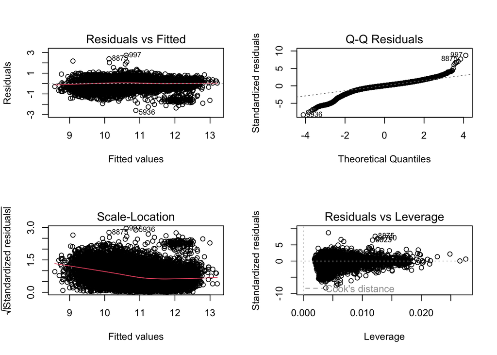

Figur 3: Diagnoseplott for modell 3.

## Tolkning av koeffisientene

Tabell 7: Prosentvis prisendring for utvalgte variabler, modell 3.

| Variabel | Koeffisient | Prisendring (%) |
| --- | --- | --- |
| Alder ved salg (per år) | −0.0080 | −0.80 |
| Solgt før byggeår (mot ferdig bolig) | −1.6156 | −80.12 |
| Tilbygd garasje (mot ingen garasje) | 0.2225 | 24.92 |
| Avstand til CBD (per km) | 0.0051 | 0.51 |
| Andel svarte i tract (per prosentpoeng) | −0.7167 | −0.71 |
| Andel uten videregående (per prosentpoeng) | −1.1302 | −1.12 |
| Andel arbeidsledige (per prosentpoeng) | −0.7159 | −0.71 |
| Nærhet til Superfund (per standardavvik) | 0.0432 | 4.41 |
| Nærhet til RMP-anlegg (per standardavvik) | −0.0355 | −3.49 |
| PM2,5 (per standardavvik) | 0.0414 | 4.22 |

**Boligegenskaper.** I modell 3 er arealelastisiteten 0,55, så 1 % større boligareal henger sammen med omtrent 0,55 % høyere pris, og elastisiteten for tomtestørrelse er 0,12. Hvert år økt alder ved salg gir omtrent 0,8 % lavere pris. Boliger med tilbygd garasje er solgt for om lag 25 % mer enn boliger uten garasje (frittstående garasje: om lag 29 %), og boliger med to eller flere etasjer for omtrent 12 % mer enn boliger med én etasje. Et ekstra bad henger sammen med omtrent 4,7 % høyere pris. Boliger solgt før byggeåret selges for omtrent 80 % lavere pris enn ellers like boliger (Tabell 7), noe som er rimelig dersom prisen bare dekker tomten eller en ufullstendig bolig. Alle disse fortegnene er rimelige. Antall rom og soverom har ingen signifikant sammenheng med prisen i modell 2 og 3, og det er forventet, siden de er sterkt korrelert med boligarealet. Arealelastisiteten faller fra 0,61 i modell 1 til 0,55 i modell 3, så en del av arealeffekten i modell 1 skyldes at større boliger ligger i dyrere områder.

**Avstand til CBD.** I oppgave 4 steg medianprisen jevnt med avstanden, fra 25 000 til 118 500 dollar (Tabell 1). Etter at vi kontrollerer for boligegenskaper og nabolag, er koeffisienten i modell 2 tilnærmet null (−0,000, t = −0,15), og i modell 3 er den 0,005 (t = 3,9), omtrent 0,5 % høyere pris per km. Prismønsteret fra oppgave 4 skyldes dermed i hovedsak at boligene og nabolagene er ulike, og ikke avstanden i seg selv. At koeffisienten først blir signifikant når miljøvariablene kommer med, kan tyde på at avstand er korrelert med dem.

**Nabolag.** Ett prosentpoeng høyere andel svarte i tracten henger sammen med omtrent 0,7 % lavere pris, mens ett prosentpoeng høyere andel uten videregående utdanning gir omtrent 1,1 % lavere pris og andel arbeidsledige omtrent 0,7 % lavere pris. Ett minutt lengre reisetid til jobb gir omtrent 1 % lavere pris, og 1 000 dollar høyere inntekt per capita omtrent 0,3 % høyere pris. Andel over 64 år og andel asiatiske har positive koeffisienter (omtrent 0,3 % og 0,8 % per prosentpoeng). Dette er betingede sammenhenger som kan gjenspeile nabolagsforskjeller vi ikke måler direkte, og ikke at beboersammensetningen i seg selv påvirker prisen.

**Miljøvariabler.** Ett standardavvik høyere nærhet til Superfund-områder (`PNPL`) henger sammen med 4,4 % høyere pris, og ett standardavvik høyere PM2,5 med 4,2 % høyere pris. Nærhet til anlegg med risikostyringsplan (`PRMP`) gir 3,5 % lavere pris per standardavvik, og det er den eneste av miljøvariablene med det forventede negative fortegnet. Andelen boliger fra før 1960 (1,6 %) og nærhet til avfallsanlegg (0,7 %) har små, positive koeffisienter, og trafikknærhet har ingen sammenheng med prisen (t = −0,47). De positive fortegnene er motsatt av forventningen om at miljøbelastning senker prisen, og tyder på at variablene fanger opp noe annet enn kjøpernes vurdering av miljøkvalitet, for eksempel beliggenhet. Bishop et al. (2020) peker på at goder er romlig korrelerte, og at man trenger eksogen variasjon i godet for å tolke estimatene som betalingsvillighet. Miljødataene er dessuten fra 2015, mens salgene er fra 1993–1998, så estimatene må tolkes som sammenhenger og ikke som kausale effekter.

# Oppgave 6

## Behov for tidsdummyer

Salgene strekker seg over flere år, så vi tester om tidsdummyene i `year_month` samlet sett har betydning for prisen. Nullhypotesen er at alle tidsdummykoeffisientene er lik 0. Vi bruker `linearHypothesis()` fra `car` på modell 3 med HC3-robuste standardfeil.

Tabell 8: Simultan F-test av tidsdummyene (modell 3, HC3).

| Antall restriksjoner | Residual-frihetsgrader | F | p-verdi |
| --- | --- | --- | --- |
| 69 | 25242 | 24.7 | < 0,001 |

Testen gir F = 24,7 med 69 og 25 242 frihetsgrader (p < 0,001). Vi forkaster dermed nullhypotesen om at alle tidsdummyene er lik null, og tidsdummyene har samlet sett betydning for prisen. Salgstidspunktet bør derfor være med i modellene, også når vi kontrollerer for boligegenskaper, nabolag og miljø.

## Tolkning av tidsdummyene

Hver tidsdummykoeffisient er forskjellen i logaritmisk pris mellom en bolig solgt i den aktuelle måneden og en ellers lik bolig solgt i referansemåneden januar 1993. Prisforskjellen i prosent er 100(*e*<sup>*β*</sup> − 1). Koeffisientene måler dermed prisnivået over tid etter at vi har kontrollert for boligens egenskaper, nabolaget og miljøet, og ikke bare den rå prisutviklingen. Siden prisene er i løpende dollar, inkluderer utviklingen også generell prisvekst.

# Oppgave 7

# Fra forelesningen:

innhenting qv ACS data: Må endre på variables. ellers kan alt av koden stå

På variabler som skal hentes inn: På linken for mer info kan man endre siste ledd for å se info om den vairabelen man ønsker

Forelesningsnotatene om Lucas county er viktig mtp. å koble boligdata og områdedata.

skal sitte igjen med antall boligsalg etter sammenslåingen av boligdata og områdedata

For avstand til CBD så finner vi akkurat det vi trenger i forelesningsnotatene fra forrige uke

Etter innlevering, bør vi gjøre det repoet privat.

Ha et eget dokument for kode, og et eget for selve artikkelen

Bishop, K. C., Kuminoff, N. V., Banzhaf, H. S., Boyle, K. J., von Gravenitz, K., Pope, J. C., Smith, V. K. & Timmins, C. D. (2020). Best Practices for Using Hedonic Property Value Models to Measure Willingness to Pay for Environmental Quality. *Review of Environmental Economics and Policy*, *14*(2), 260–281. https://doi.org/10.1093/reep/reaa001